# Module 11 Lecture - Personality

Introductory Psychology

Quinton Quagliano, M.S., C.S.P

Department of Psychology

# 1 Overview and Introduction

Agenda

1 Overview and Introduction

2 What is Personality?

3 Freud and the Psychodynamic Perspective

4 Neo-Freudians: Adler, Erikson, Jung, and Horney

5 Learning Approaches

6 Conclusion

## 1.1 Textbook Learning Objectives

- Define personality
- Describe early theories about personality development
- Describe the assumptions of the psychodynamic perspective on personality development
- Define and describe the nature and function of the id, ego, and superego
- Define and describe the defense mechanisms
- Define and describe the psychosexual stages of personality development
- Discuss the concept of the inferiority complex
- Discuss the core differences between Erikson’s and Freud’s views on personality
- Discuss Jung’s ideas of the collective unconscious and archetypes
- Discuss the work of Karen Horney, including her revision of Freud’s “penis envy”
- Describe the behaviorist perspective on personality
- Describe the cognitive perspective on personality
- Describe the social cognitive perspective on personality

## 1.2 Instructor Learning Objectives

- Be able to classify theories under the general category they belong to, and identify the perspective/paradigm that the respective theorists belong to
- Appreciate the complexity of different perspectives in personality theories - compare and contract this with the diverse theories of learning, development, etc.
- Be able to differentiate between the different foci of different theories, and use the correct vocabulary when describing them

## 1.3 Introduction

- **Discuss: Think of your closest friend or acquaintance - in single word, e.g. 'mean', give some descriptors of their personality**
- We have an intuitive sense of people’s personality, but a whole field of empirical research has much clearer explanations of the *how* and *why* our personality is the way it is

# 2 What is Personality?

Agenda

1 Overview and Introduction

2 What is Personality?

3 Freud and the Psychodynamic Perspective

4 Neo-Freudians: Adler, Erikson, Jung, and Horney

5 Learning Approaches

6 Conclusion

## 2.1 Introduction

- Our **personality** is a set of long-standing traits and patterns of thoughts, feelings, and behaviors that drive our interactions with others and play into our outcomes in life
  - But within that broad perspective, there are a lot of different perspective and theories as to the *how* and *why*
- **Question: If we are to describe personality as being 'long-standing', which of the following things is most likely a personality trait**
- A) Depressive mourning following the death of a loved one
- B) Bliss from finishing a college semester
- C) Chronic aggression towards friends and family
- D) Frustration from a home-work problem
- **Important: It's been said several times before, but having many theories to explain the same observations is a common situation in psychological science**

## 2.2 Historical Perspectives

- Like early philosophers opining on the human behavior and mind, they also gave many theories regarding personality
- The **four-humors theory** : personality is based upon the relative amount 4 different fluids in the body
  - An imbalance of these fluids could result in bad personality or behavior - balance was desired
  - Choleric temperament: yellow bile from the liver; ambition, short-tempered, aggressive
  - Melancholic temperament: black bile from the kidney; sadness, depression
  - Sanguine temperament: red blood from the heart; enthusiastic, social, active
  - Phlegmatic temperament: white phlegm from the lungs; reserved
- **Question: Under the four humors theory, which of the following behaviors would like be associated with too high amount of red blood**
- A) Sulking around and not leaving the house
- B) Being overly flamboyant, loud, passionate
- C) Being too shy to talk to new acquaintances
- D) Always trying to get promoted at work, to others' expense
- **Discuss: The four humors theory hinges on 'balance' of the fluids - what more modern idea in psychology and physiology is also connected to balance of things in our body?**
- **Phrenology theory**

  personality and temprament can be understood by taking many measurements of the skull that, hypothetically, described the underlying brain
- Galen’s theory:

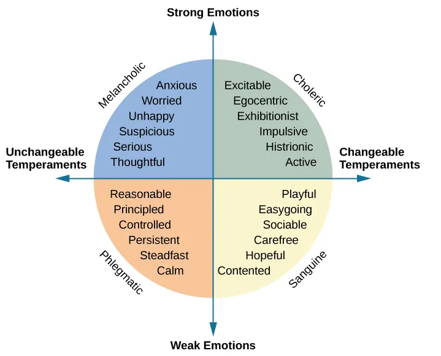

- **Important: While these may seem far-fetched today, they were well-respected theories for some time! There are likely to be modern theories in medicine in psychology that we will laugh at 30 years from now.**

# 3 Freud and the Psychodynamic Perspective

Agenda

1 Overview and Introduction

2 What is Personality?

3 Freud and the Psychodynamic Perspective

4 Neo-Freudians: Adler, Erikson, Jung, and Horney

5 Learning Approaches

6 Conclusion

## 3.1 Introduction

[figure not shown]

- Much like Freud had ideas on development, the unconscious and dreams, he also had something to say about personality
- Freud’s early foray into the psychological came with the study of Anna O., a pseudonym for Bertha Pappenheim
  - He hypothesized that she suffered hysterical symptoms like, hallucinations and amnesia related to past trauma and abuse
  - But, this trauma had been hidden in the unconscious, “Anna” was not aware of it
- **Important: Remember, with Freud it always comes back to the unconscious!**

## 3.2 Levels of Consciousness

- In Freud’s view, there are levels between our conscious and unconscious

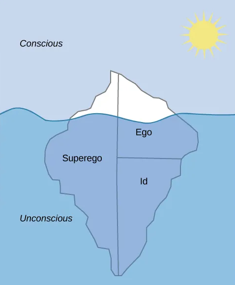

- The **conscious** is what thoughts, feelings, and memories we are aware of, while the **unconscious** are things we are not aware of, or cannot access.
- **Discuss: Write down an unconcious memory you have of your childhood**
- In Freud’s view, our personality is related to the interaction between three components:
  - Id
  - Superego
  - Ego
- The **Id**
  - Primitive drives, urges instincts and needs
  - Works on the **pleasure principle**
- **Discuss: Which theory of motivation dealt with concepts similar to the above description of the id?**
- The **Superego**
  - Acts as our conscience and moral compass
  - Causes feelings of guilt when we do something wrong or indecent
- **Important: Because of their opposite natures, our id and superego are always in conflict with one another!**
- The **Ego**
  - Balances the desires of both the id and the superego by being rational
  - Works on the **reality principle**

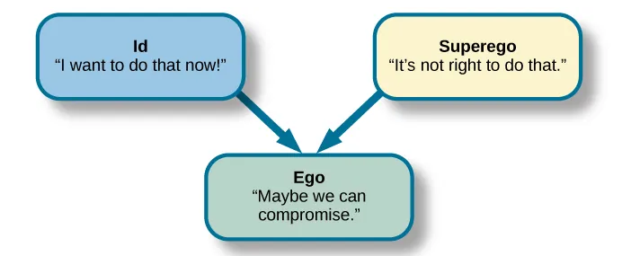

- **Question: In class, I am hungry, so I pull out a triple hamburger and begin eating it as I lecture - what part of the above trio am I listening to?**
- A) Id
- B) Superego
- C) Ego
- D) None of the above
- Freud hypothesized that if we are unable to balance the warring id and superego, we may be in a state of **neurosis**
  - Thus, our anxiety can be traced back to the ego trying to moderate the id and superego

## 3.3 Defense Mechanisms

- Our ego desired a low state of anxiety, and thus, may employ unconscious **defense mechanism**
- There are many types of defense mechanisms that one might employ:

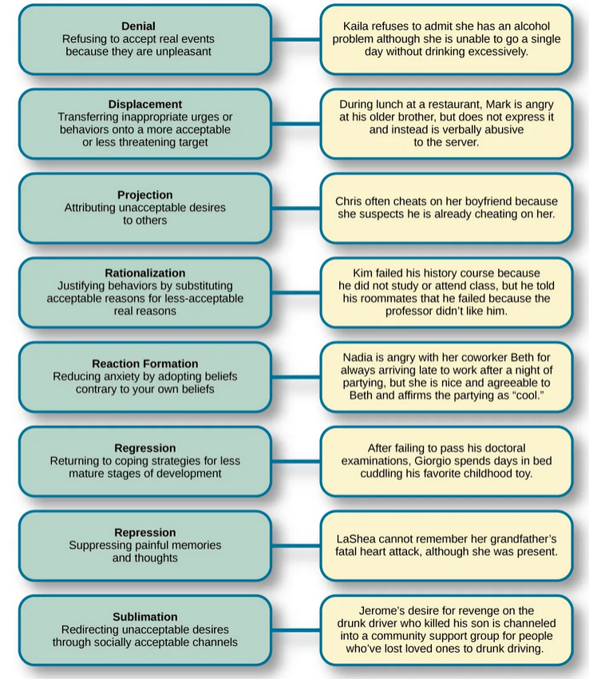

- **Discuss: Identify the two possible defense mechanisms being employed in this example: Drake is fighting with his brother, Josh. Earlier that day Drake got both of them stuck in a treehouse by accidentally closing it without a door. Drake insists that he indeed put a hole in the door, despite that being clearly not the case. Then, he insists that he only made the mistake because he was hungry while they were working.**
- The [inspiration for the prior question](https://www.youtube.com/watch?v=u-GXQvrlmXE&pp=ygUfd2hlcmUncyB0aGUgZG9vciBkcmFrZSBhbmQgam9zaA%3D%3D)

## 3.4 Stages of Psychosexual Development

- **Important: Freud was not just a deviant (well maybe a little in some regards), but his theories came about because of how taboo and repressed sex was as a topic during his time**
- Returning to Freud’s stages of development, recall that he believes that our childhood has later impacts on our life
  - His stages, as we’ll cover more in a second, are related to the **erogenous zone**

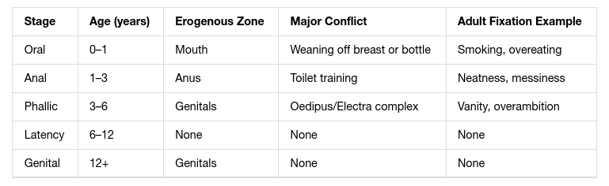

- **Question: Which of the following ways would be appropriate to describe Freud's theory of development?**
- A) Continuous
- B) Discontinuous
- C) Disadvantageous
- D) Empirical
- Freud said it is possible to fall into **fixation**

### Oral Stage

- The **oral stage** of development is focused on the mouth
  - During childhood: E.g., sucking on mother’s breast, pacifiers, thumbs, etc
  - How fixation occurs: weaning too early or too late, resulting in anxiety
  - During adulthood if fixation occurs: E.g., excess smoking, eating, drinking, biting nails
- **Discuss: If we say that weaning too early can harm a young child's trust, and inspire mistrust - what theory (and associated theorist) might this conflict be associated with?**

### Anal Stage

- The **anal stage** of development is focused on the anus (and bladder)
  - During childhood: mastering control over toilet training and inhibiting urination and defecation
  - How fixation occurs:
    - Too strict or harsh parenting $\rightarrow$ anal-retentive
    - Too lenient parenting $\rightarrow$ anal-expulsive
  - During adulthood if fixation occurs:
    - Anal-retentive: stingy, stubborn, perfectionism
    - Anal-expulsive: messy, careless, disorganized
- **Discuss: If I am super cheap and very fixated on having an organized workplace, becoming angry when people move things, Freud would say what about the parenting that I had during potty training?**

### Phallic Stage

- The **phallic stage** of development is focused on the genitals
  - Children begin to understand the differences between sexes
  - During childhood: a desire towards the opposite-sex parent, jealousy towards the same-sex parent
    - In boys: Oedipus complex, castration anxiety
    - In girls: Electra complex, penis envy
  - How fixation occurs: inability to resolve an understanding of the parent as a non-opponent
  - During adulthood if fixation occurs: vain, overly ambitious
- **Discuss: Try explaining the conflict in this stage through the vocabulary of the id, the ego, and the superego**

### Latency Stage

- During this **latency stage**, there is actually a lack of sexual feelings, as children focus on other pursuits and goals
  - “Latency” means “delay”

### Genital Stage

- The **genital stage** of development is, again, focused on the genitals
- Compared to the phallic stage, a young adult now redirects the original incestuous feelings from their Oedipus or Electra Complex into desire for more socially acceptable partners
- **Important: You can't really become 'fixated' at this stage, as it is the final one**

## 3.5 Conclusion

- Freud’s thoughts on the ego, superego, id, and all of the stages of psychosexual development come back to what type of adult we become, i.e., our personality
- **Important: Many developmental theories tie into personality because many theories how that our development is critical for shaping us**
- **Question: A hot-shot, well-paid lawyer is fantastic at their job, but incredibly self-centered, focused only on their own good by continuing to excel in their career. What stage might Freud say this person is stuck in?**
- A) Oral
- B) Anal
- C) Phallic
- D) Genital

# 4 Neo-Freudians: Adler, Erikson, Jung, and Horney

Agenda

1 Overview and Introduction

2 What is Personality?

3 Freud and the Psychodynamic Perspective

4 Neo-Freudians: Adler, Erikson, Jung, and Horney

5 Learning Approaches

6 Conclusion

## 4.1 Introduction

- “Neo”-Freudian $\rightarrow$ “New” Freudians, i.e., those who modified and added to his psychosexual theory
- Most of these theorists took a diminished role of sex in development, and instead focused on other areas

## 4.2 Alfred Adler & Individual Psychology

- Alfred Adler place intense emphasis on feelings of inferiority, i.e., the **inferiority complex**
  - In his perspective, our personality is determined as a result of trying to “make up” for feelings of inferiority during childhood
- Adler took a more social view of development of personality, as our relation to other in society and our feelings of how well we “stack up” determines our personality
  - He talked of **social tasks** that we consider if we feel inferior in
    - Occupational tasks
    - Societal tasks
    - Love tasks
  - Any sense of inferiority in the above tasks made lead to a change in personality
- **Discuss: Describe a situation in which someone may feel a sense of inferiority in their occupational tasks**

## 4.3 Erik Erikson (Again)

- Erik Erikson also falls into this general neo-Freudian category, as he continued the emphasis of the childhood, but also place value on the lifespan and social milestones as well
  - See prior module notes for more details on his theories
  - Similar to Adler, Erikson held that failure in any of the developmental tasks could lead to longstanding issues in traits

## 4.4 Carl Jung & Analytical Psychology

- Carl Jung provided the new theory of **analytical psychology**
  - This was focused on the development of balance between unconscious and conscious desires
- Jung was also the first to make a disinfection of extroverts and introverts:

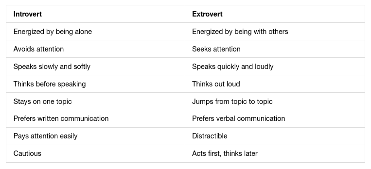

- **Discuss: Would you describe yourself more as an extrovert or an introvert? Give some examples of why you think this way**

## 4.5 Karen Horney & Extension of Psychoanalysis

- Karen Horney was Freudian-trained, but moved her area of interest more toward positive growth, self-realization, and improving - regardless of childhood issues or development
- **Question: Which of these other perspectives had a focus on positive growth?**
- A) Psychoanalysis
- B) Behaviorism
- C) Cognitivism
- D) Humanism
- Because she focused on how we grow past anxiety, she introduced the following coping styles to explain the different ways we think and behave to reduce our anxiety

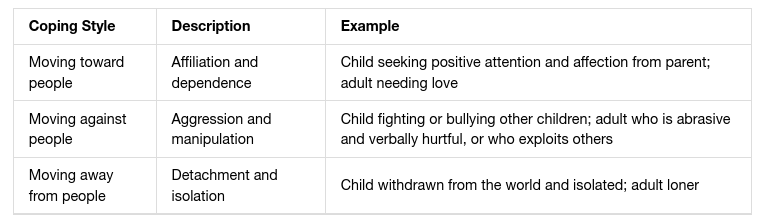

# 5 Learning Approaches

Agenda

1 Overview and Introduction

2 What is Personality?

3 Freud and the Psychodynamic Perspective

4 Neo-Freudians: Adler, Erikson, Jung, and Horney

5 Learning Approaches

6 Conclusion

## 5.1 Introduction

- Much like the broader perspective of behaviorism, the following theories on personality are mostly related to observable behaviorism
- **Discuss: How does that differ from those perspectives above with Freud and the neo-Freudians? What is one advantage that behaviorism has over these other theories? Hint: think research**

## 5.2 Behavioral Perspective

- As mentioned prior, B.F. Skinner was a radical behaviorist, i.e., someone who believes all human thoughts, actions, and behaviors are the results of form of conditioning
- **Question: Review: which specific type of conditioning was B.F. Skinner often associated with?**
- A) Classical
- B) Operant
- C) Observational
- D) Vicarious
- The behaviorist perspective holds that our tendency to maintain or change our personality can be across the lifespan, and is a result of:
  - Reinforcment
  - Punishment
  - Observational learning
  - Associative learning
- Example: I drive fast and recklessly on the road, until I get in a bad car accident which causes me chronic pain - I change my tendencies towards riskiness due to this consequence
- **Question: In the above example, what would we call the pain as a consequence?**
- A) Negative Reinforcement
- B) Positive Reinforcement
- C) Negative Punishment
- D) Positive Punishment

## 5.3 Social-Cognitive Perspective

- Albert Bandura, another behaviorist held what he called the **social-cognitive theory of personality**
  - This rested upon **reciprocal determinism**

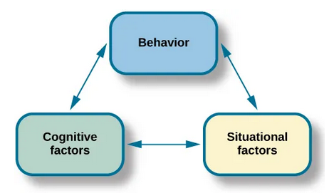

- This is closely related to observational learning, and the vicarious punishment/reinforcement that comes with it
  - We adopt the personalities and actions that we see are rewarded in other people
  - E.g., I see that being a jerk got one guy multiple promotions at my company, thus I become a jerk to succeed as well because it is good
- **Discuss: What stage of Kohlberg's Theory of Moral Development might we be at if we judge our morality purely on reinforcement and punishment?**

# 6 Conclusion

Agenda

1 Overview and Introduction

2 What is Personality?

3 Freud and the Psychodynamic Perspective

4 Neo-Freudians: Adler, Erikson, Jung, and Horney

5 Learning Approaches

6 Conclusion

## 6.1 Recap

- There are many competing, but valid, theories of personality that offer explanations for how and why personality develops a certain way
- Each of these theories places value on different areas that may cause longstanding changes in our traits, attitudes, thoughts, feelings, and behaviors
- Many of these theories relate to previous topics, such as development, behaviorism, cognitivism, etc.

## 6.2 Lecture Check-in

- Make sure to complete any lecture check-in tasks associated with this lecture!

[figure not shown]

Module 11 Lecture - Personality || Introductory Psychology